# Latent trait analysis

Memo to Kyra and Mark

I was searching around for tools that do latent network space modeling more quickly, and found the lvm4net package (https://cran.r-project.org/web/packages/lvm4net/lvm4net.pdf). It’s more standalone than latentnet, which integrates nicely with statnet and ergm capabilities. But on the upside, it is *very* fast and turns out it has some really cool tools.

Firstly, it performs latent trait analysis (see https://arxiv.org/abs/1301.2167 and https://arxiv.org/abs/1905.02659, same author as lvm4net package). The basic idea in this case is that the concepts survey respondents selected are essentially categorical traits. There’s a lot of stats talk and monkey business behind that, but here’s the upshot…

#ignore this chunk, ut just loads and builds network object

```r
getwd()
```

```
[1] "/home/master/SLRSurvey"
```

```
There were 16 warnings (use warnings() to see them)
```

```r
#convert to incidence matrix
Y = as.sociomatrix(bip_net)
#run lta with 1 to 4 dimensions
d_list = lapply(1:4,function(d) lta(Y,D = d))
```

```r
mod = d_list[[2]]
#intercepts
print(mod$b)
```

```
     Item 1    Item 2    Item 3    Item 4    Item 5    Item 6    Item 7     Item 8    Item 9  Item 10   Item 11   Item 12   Item 13    Item 14   Item 15
 -0.6087276 -1.173121 -2.118473 -1.420511 -1.267826 -1.592972 -1.782714 -0.9474469 -2.024361 -1.80067 -2.773688 -1.971604 -1.325542 -0.6546691 -2.527286
   Item 16   Item 17   Item 18   Item 19    Item 20   Item 21   Item 22    Item 23   Item 24   Item 25   Item 26  Item 27   Item 28   Item 29   Item 30   Item 31
 0.5269021 -1.405377 0.2567792 -2.704912 -0.8015874 -1.539972 -3.452217 -0.2397416 -2.549424 -2.893296 -1.995168 -2.07186 -2.914928 -1.541766 -1.191777 -2.542208
   Item 32   Item 33   Item 34   Item 35   Item 36    Item 37   Item 38   Item 39   Item 40   Item 41
 -2.633407 -1.142943 -1.756493 -3.113335 -2.580487 -0.4535195 -1.817995 -1.503129 -2.078597 -1.668226
```

```r
#slopes
print(mod$w)
```

```
          Item 1     Item 2     Item 3     Item 4    Item 5     Item 6     Item 7     Item 8     Item 9    Item 10    Item 11    Item 12    Item 13    Item 14
Dim 1 -0.5980053 -0.1342512 0.05589974  0.1477577 0.4910503 -0.2171941 -0.3567625  0.5039184 -0.1056691  0.2027441  0.1869131 -0.1470130 -0.3195770 0.10757986
Dim 2  0.7185156  0.1741524 0.03917159 -0.1730876 0.2546038  0.2118687 -0.8604976 -0.1040013 -0.1243820 -0.0880456 -0.1753685 -0.1044261  0.1077552 0.09214217
         Item 15    Item 16    Item 17    Item 18   Item 19    Item 20   Item 21    Item 22    Item 23    Item 24    Item 25    Item 26    Item 27    Item 28
Dim 1  0.1443732 -0.2713767 0.04884988 0.01061044 0.0381435  0.7280505 0.4703907 -0.1589800 -0.7256382 -0.1387138 0.04034199 -0.1862620 -0.1583112  0.2194305
Dim 2 -0.3443425  0.4767900 0.13910498 0.65051160 0.1197765 -0.1431415 0.1978549  0.1741337 -1.0219719  0.0796356 0.15595367 -0.1824952 -0.4028605 -0.1782908
         Item 29    Item 30     Item 31    Item 32      Item 33    Item 34    Item 35     Item 36    Item 37   Item 38     Item 39    Item 40     Item 41
Dim 1 -0.1153376  0.1491588  0.02351888 0.27500172 -0.003958351 -0.1934151 0.08503486 -0.08970502 -0.4077206 0.5081364 -0.08228364 -0.2140005  0.07794615
Dim 2 -0.2639442 -0.2904674 -0.06442258 0.04082031  0.100955583  0.3915726 0.12724049 -0.20737082  0.5327795 0.3727723  0.18820075 -0.4067113 -0.21924894
```

```r
unique( (bip_net %v% 'Actor_Type')[{bip_net %v% 'Concept_Type'}=='Person'])
```

```
 [1] "Other"                                                                    "Education/Consulting/Research"
 [3] "No-profit organization/Non-governmental organization"                     "Other (please explain)"
 [5] "Local government (cities, counties)"                                      "Environmental Group"
 [7] "Trade/Business/Industry Group"                                            "Regional government"
 [9] "Environmental Special District (e.g. Park district, open space district)" "State government"
[11] "Community-based organization"                                             "Water Infrastructure Special District (e.g. irrigation district)"
[13] "Federal government"
```

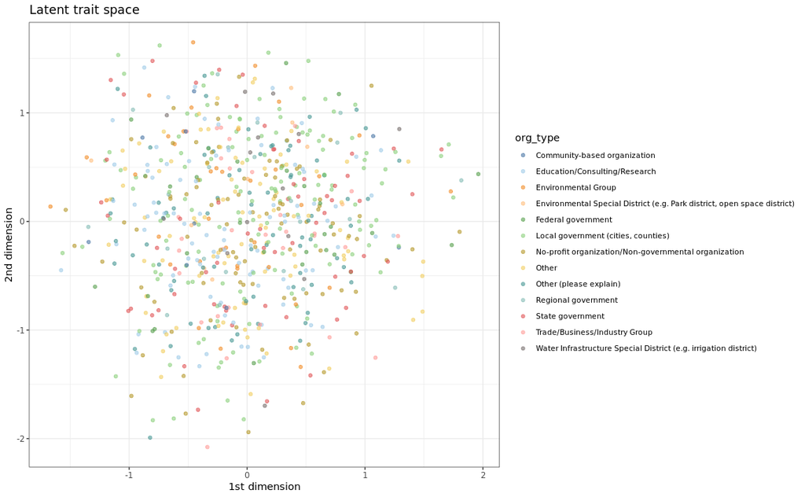

```r
trait_space = data.table(mod$mu)
trait_space$org_type = (bip_net %v% 'Actor_Type')[{bip_net %v% 'Concept_Type'}=='Person']
ggplot(trait_space) + geom_point(aes(x = V1,y = V2,col = org_type),pch = 19,alpha = 0.6) + xlab('1st dimension') +
  ylab("2nd dimension") + ggtitle('Latent trait space') + theme_bw() +
  scale_color_tableau(palette ='Tableau 20')+   scale_fill_tableau(palette ='Tableau 20')+
  theme(legend.text = element_text(size = 8))
```

Doesn’t seem to be a stark pattern at this point between actor type and location. But it’s tough to see acrsoss 10+ types anyways, so a simplied lens likely sheds more light.

The next thing that is feasible is a ‘mixture of latent trait analyzers’ (MLTA) model; real talk, I need to reread the arxiv paper again, because I can’t explain this very well. But the tl;dr is that it incorporates a group structure (like the clusters we’ve been discussing). To keep it simple, I’ll just use the 2-d model. The code also allows for different slopes by group (for logistic response function) but I turned that off.

```r
groups = 1:4
g_list = lapply(groups,function(g) mlta(X = Y,D = 2,G = g,wfix = T))
names(g_list) <- paste0('G',groups)
print(sapply(g_list,function(x) x$BIC))
```

```
G1.BIC (G-H Quadrature correction): G2.BIC (G-H Quadrature correction): G3.BIC (G-H Quadrature correction): G4.BIC (G-H Quadrature correction):
                           25088.58                            25195.38                            25313.72                            25477.84
```

What is not particularly promising here is that BIC scores prefer the G = 1 option… so not that fun. The G = 2 option is pretty close GOF wise, so we’ll continue with that. When there are multiple groups fit, there are cool results like the probability of membership in each group for each node:

```r
head(round(g_list[[2]]$z,2),20)
```

[output not shown]

Since G = 2, 1 - p(g1) = p(g2). We can compare across org types:

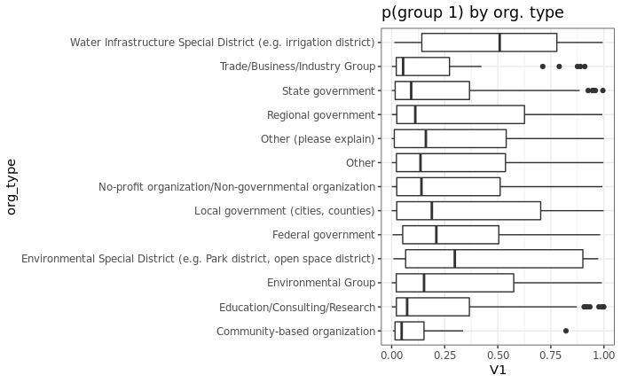

Just for kicks, here’s G = 3…

```r
p_3group = data.table(g_list[[3]]$z,org_type = trait_space$org_type)
p3 = melt(p_3group)
```

```
id.vars and measure.vars are internally guessed when both are 'NULL'. All non-numeric/integer/logical type columns are considered id.vars, which in this case are columns [org_type]. Consider providing at least one of 'id' or 'measure' vars in future.
```

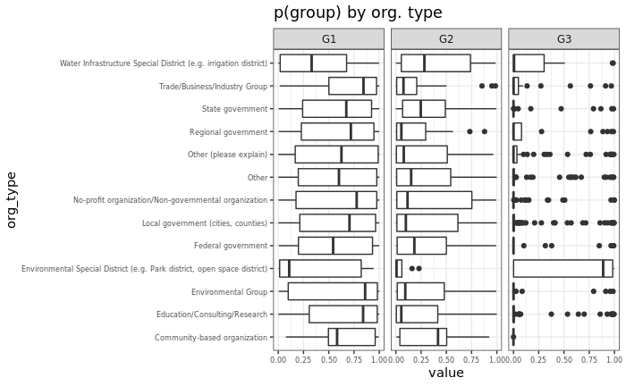

```r
p3$variable <- gsub('V','G',p3$variable)
ggplot(p3) + facet_wrap(~variable,ncol = 3) + geom_boxplot(aes(y = value,x = org_type)) +
  coord_flip() + theme_bw() + ggtitle('p(group) by org. type') + theme(axis.text = element_text(size = 6))
```

Instead of the latent trait analysis above, can also fit latent class analysis on the bipartite network. First example, 2 groups:

```r
m_lca = lca(X = Y,G = 2)
```

lca() outputs p-values for the conditional probability of observed a link between a concept and an actor if the concept is in group X.

```r
m_lca$p
```

```
             p_g1      p_g2      p_g3      p_g4      p_g5      p_g6       p_g7      p_g8      p_g9     p_g10      p_g11     p_g12     p_g13     p_g14      p_g15
Group 1 0.4982167 0.2688737 0.1052578 0.1680593 0.2857524 0.2137677 0.04461354 0.2757142 0.1028325 0.1324323 0.03762782 0.1162704 0.2307803 0.3734821 0.01301002
Group 2 0.1767100 0.1920926 0.1106782 0.2378288 0.1459798 0.1102899 0.35586269 0.3024658 0.1390479 0.1592221 0.09337290 0.1334280 0.1879696 0.2966420 0.17213866
            p_g16     p_g17     p_g18      p_g19     p_g20     p_g21      p_g22     p_g23      p_g24      p_g25     p_g26      p_g27      p_g28     p_g29
Group 1 0.6926561 0.2093194 0.6531869 0.07826173 0.3054941 0.2204640 0.04793643 0.3004063 0.09207040 0.06450333 0.1032197 0.07115546 0.02822856 0.1365805
Group 2 0.5209338 0.1806071 0.4231876 0.04061597 0.3471728 0.1323111 0.00733992 0.6699543 0.04507774 0.03608016 0.1491054 0.18569905 0.08950247 0.2416772
            p_g30      p_g31      p_g32     p_g33      p_g34      p_g35     p_g36     p_g37      p_g38     p_g39      p_g40     p_g41
Group 1 0.1801964 0.06172448 0.06765420 0.2518662 0.21735326 0.05915504 0.0451703 0.4830593 0.20139384 0.2069858 0.06574111 0.1179087
Group 2 0.3191462 0.08976855 0.07040808 0.2277674 0.05895591 0.01915867 0.1106055 0.2663413 0.07891698 0.1486181 0.19367283 0.2231221
```

and lca() outputs p-values for the probability that each *actor* is part of group G:

```r
head(round(m_lca$z,2),10)
```

```
      [,1] [,2]
 [1,] 0.64 0.36
 [2,] 0.30 0.70
 [3,] 0.27 0.73
 [4,] 0.87 0.13
 [5,] 0.02 0.98
 [6,] 0.02 0.98
 [7,] 0.01 0.99
 [8,] 0.05 0.95
 [9,] 0.05 0.95
[10,] 0.38 0.62
```

```r
lca_compare_G = lca(X = Y,G = 1:5)
```

```
numerical expression has 5 elements: only the first usedError in sample.int(x, size, replace, prob) :
  incorrect number of probabilities
```